# Sediments

## Prompt

Given the attached dataset:

1.Divide the site into spatial and depth “zones” (groups, regions, strata) based on chemistry of Total PCBs, Arsenic, and PAHs.

2.Are there upstream to downstream patterns? If so, what are the differences between chemicals?

3.Describe the trends you found and the tools/approaches that you used. Provide PDF maps, tables, and statistics depicting the spatial zones, strata, and groupings.

# Data Prep

With some snooping around the data source, I’ve determined that this is Duwamish Waterway, running through the rougher, industrial neighborhoods of south Seattle.

```r
rm(list=ls()) # Clear working environment
library("MapSuite") #Self-written library, has many common libs as dependencies

# Load in data, which is a spatialpointsdataframe
  chem_sp<-readRDS("Dataset_B.RDS")

# Let's get the data out from the spatial object
  chem_data<-data.table(chem_sp@data)
  chem_data[,sp_index:=seq(1:nrow(chem_data))]

# OK, there are way too many unhelpful columns in this dataset; let's parse it down
  chem_data<-chem_data[,list(sp_index,X,Y,RM,
                             UpperDepth_cm,LowerDepth_cm, Unit,
                             Chemical,ChemicalGroup, SampleDate,
                             Detected, observed_value=ValueOrHalfQL,dredged_flag=FE_NAVCHAN_F)]

# make one field that describes what chemical we are interested in; that way we don't have to subset
# off of Chemical *or* ChemicalGroup depending on the analyte
  chem_data[Chemical=="Arsenic",chem:="Arsenic"]
  chem_data[Chemical=="Total PCBs",chem:="PCBs"]
  chem_data[ChemicalGroup=="PAHs",chem:="PAHs"]

# Make decimal date
  chem_data[,decimal_date:=lubridate::decimal_date(SampleDate)]

# Some basic cleanup: I only want to know about samples that have a valid entry for "Detected", and that
# have non-NA values for observed chemical value
  chem_data<-chem_data[!is.na(Detected)&!is.na(observed_value)]

# What year was each sample taken? Extract from the sample time.
  chem_data[,Year:=as.numeric(substr(as.character(chem_data$SampleDate),1,4))]

# Let's try a log-transform for the value variables; this might be useful later on
  chem_data[,log_value:=log(observed_value)]

# Adding a column of "noise" to be able to jitter our plots
  chem_data[,noise:=rnorm(nrow(chem_data),mean=0,sd=.2)]
```

To make looping through the different chemicals easier, I’ve made a named list with a specific color pallete to keep them straight, and their units.

```r
# Making a structured list for each of the chemicals with data sets, units, and
chemlist<-list()
chemlist[["PAHs"]]<-list(colors="foliage",name="PAHs",unit="ug/kg dw")
chemlist[["Arsenic"]]<-list(colors="ocean",name="Arsenic",unit="mg/kg dw")
chemlist[["PCBs"]]<-list(colors="berries",name="PCBs",unit="ug/kg dw")
```

I also find the fact that River-Miles are based on distance from the mouth of the stream’s outlet to the ocean, rather than distance from the furthest upstream point, to be confusing, and I like my graph and chart axes such that “trajectory” is moving away from the lowest value. To make this more straightforward, I’ll create a “flipped” river-mile counter, in which the measurement represents the distance from the furthest-upstream-point measured in the data set.

```r
chem_data[,RM_up:=max(RM,na.rm=T)-RM]
```

## Step 1: Define depth strata based on common sampling depth combinations

The first step here is to determine different “layers” of sediment we are interested in– to do this, we need to know what samples were taken, and where– is there a consistent pattern of depths cored? To scope this out, I made some graphs by river-mile and depth core, to see what patterns appear in the data.

This is naive to things like river bottom depth, but it’s a good first stab.

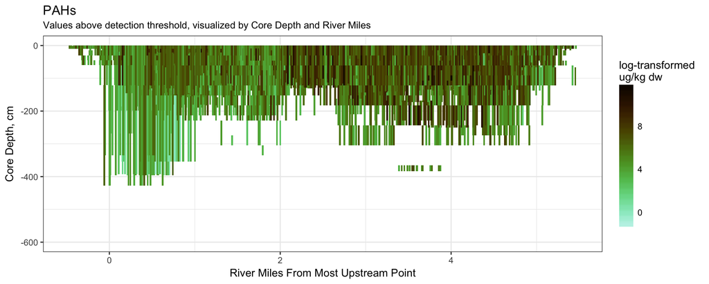

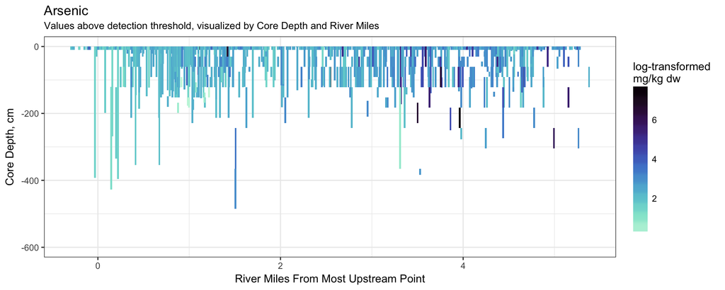

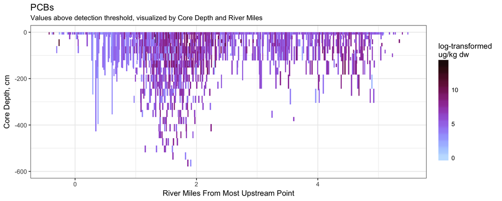

```r
for (chemical in names(chemlist)){
  chem_info<-chemlist[[chemical]]

  p1<-ggplot() +
    # Rectangles to simulate core depths and values
     geom_rect(data=chem_data[chem==chemical & Detected=="Yes",],
              aes(xmin=RM_up+noise, xmax=RM_up+noise+.02, # River-mile as x-axis, plus some noise for
                                                    # differentian of samples and artificial width
              ymin=-1*UpperDepth_cm, ymax=-1*LowerDepth_cm,  # Use upper/lower limit as core sample depth limits
              fill=log_value)) + # Color by log-value

    # Formatting and Labeling
    ggtitle(chem_info[["name"]],
            subtitle="Values above detection threshold, visualized by Core Depth and River Miles") +
    xlab("River Miles From Most Upstream Point") + ylab("Core Depth, cm") +
    theme_bw() + scale_fill_gradientn(colors=wpal(chem_info[["colors"]])) +
    guides(fill=guide_colourbar(title=paste0("log-transformed \n",chem_info[["unit"]]),
                                title.position="top", barheight=10,
                                barwidth=1, label=TRUE, ticks=FALSE,
                                direction="vertical"))+ylim(-600,0)

  print(p1)
}
```

It looks like there are many different common core sampling depths, but, to keep this analysis tractable, we’ll stick with 4 zones: “Surface”, with the midpoint of the sample falling between 0-10 cm, “Near-Surface”, with the midpoint depth of the sample falling between 10cm and 2 feet deep, “Mid-layer”, with samples between 2-6 feet deep, and “Deep”, with all samples beyond 6 feet below the river bottom. Some of these cores may span more than one of these categories– to aoid “double-counting” the data points in multiple sedimentary strata, I’ll use the depth midpoint of the core sample to assign categories.

```r
# Generate factor-data-type classification based on sample depth with defined cut-points
    chem_data[,sample_midpoint:=(LowerDepth_cm+UpperDepth_cm)/2] # Generate mid-point of core samples
    chem_data[,Depth:=cut(sample_midpoint,breaks=c(0,10,61,182,10000),
                          labels=c("Surface","Near-Surface","Mid-Layer","Deep"))]
    chem_data[,Depth:=as.factor(Depth)]
```

Let’s create the categories, and sanity-check that they seem to be in the right categories based on one of the chemicals:

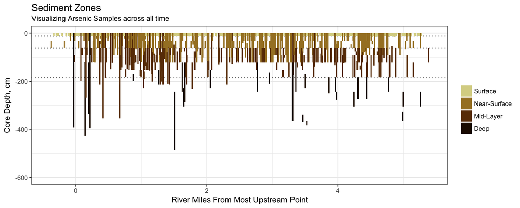

```r
# Make a sanity-check Plot

  # Define a color pallette for the factor variable, Depth
  SedColors<-wpal("warm_brown",noblack=T,n=4)
  names(SedColors) <- c("Surface","Near-Surface","Mid-Layer","Deep")

  # Make GGplot
  zone_plot<-ggplot() +
    # Show zones as dotted lines underneath data plots
          geom_hline(yintercept = -10, linetype="dotted") + # Boundary for Shallow and Near-Surface
          geom_hline(yintercept=-61, linetype="dotted") +  # Boundary between Near-Surface and Mid-layer
          geom_hline(yintercept=-182, linetype="dotted") + # Boundary between Middle and Deep Zone
    # Show cores in their respective zones
            geom_rect(data=chem_data[chem=="Arsenic",],
                    aes(xmin=RM_up+noise, xmax=RM_up+noise+.02,
                    ymin=-1*UpperDepth_cm, ymax=-1*LowerDepth_cm, fill=Depth)) +
          scale_fill_manual(name = "",values = SedColors, drop=F) +
          xlab("River Miles From Most Upstream Point") + ylab("Core Depth, cm") +ylim(-600,0) +
          ggtitle("Sediment Zones", subtitle="Visualizing Arsenic Samples across all time") + theme_bw()

     print(zone_plot)
```

We can see that some of the samples do indeed cross strata lines, but for the most part, this looks good, and a relatively clean representation of depth strata for the samples.

It’s an over-simplification, but for now, I’m just going to ignore x-y position in favor of River Miles.

[figure not shown]

```r
#for (chemical in names(chemlist)){
chemical<-"Arsenic"
      chem_info<-chemlist[[chemical]]

      p1<-ggplot() +
        # Rectangles to simulate core depths and values
         geom_point(data=chem_data[chem==chemical &
                                     dredged_flag=="N" &
                                     Depth=="Surface"],
                  aes(y=SampleDate,x=RM_up,
                  color=log_value)) + # Color by log-value

        # Formatting and Labeling
        ylab("Sample Date") + xlab("Distance from Ocean (miles)") +
        ggtitle(chem_info[["name"]],
                subtitle="Observations Above Detection Threshold") +
        theme_bw() + scale_color_gradientn(colors=wpal(chem_info[["colors"]])) +
        guides(color=guide_colourbar(title=paste0("log-transformed \n",chem_info[["unit"]]),
                                     title.position="top", barheight=10,
                                    barwidth=1, label=TRUE, ticks=FALSE, direction="vertical"))

      print(p1)
```

```r
#}
```

Since there are observations in each river-mile from one bank to another, let’s reduce the dimensionality even more, and create some summary statistics for each tenth of a river mile, and year combination.

```r
chem_<-chem_data[!is.na(chem) & Detected=="Yes", # Restrict data to only the analytes we care about, and
                                                           # where it was detected
                           list(obs_max=max(observed_value),
                                obs_mean=mean(observed_value),
                                Unit),
                           by=c("chem","Year","RM_up")] # Do these summary statistics for each chemical,
                                                # in each year, for each tenth-of-a-river-mile combination,
                                                # for dredged and un-dredged sediments.

chem_simplified<-chem_data[!is.na(chem) & Detected=="Yes", # Restrict data to only detected values of the 3 chems
                           list(obs_max=max(observed_value), obs_mean=mean(observed_value), Unit),
        # Do these summary statistics for each chemical, year, dredge-category, depth-category,river-tenth-mile
                           by=c("chem","Year","RM_up","dredged_flag","Depth")]
```

There is no uncertainty with these measurements..

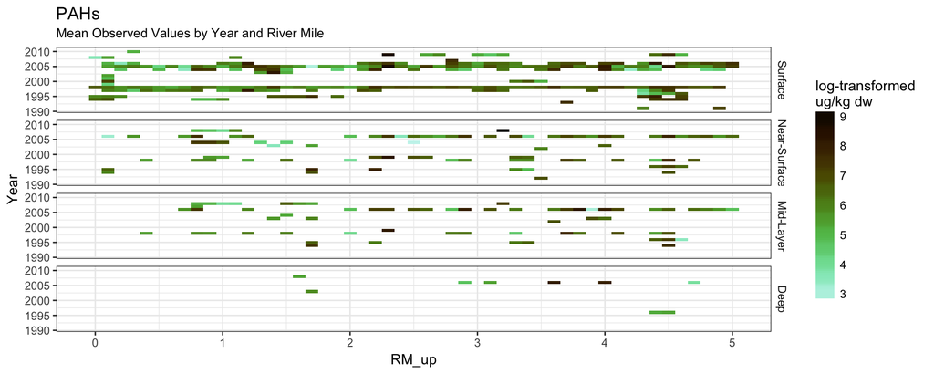

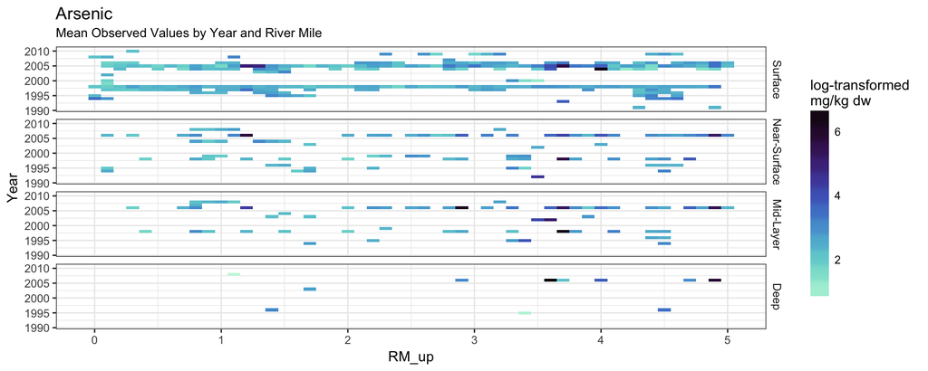

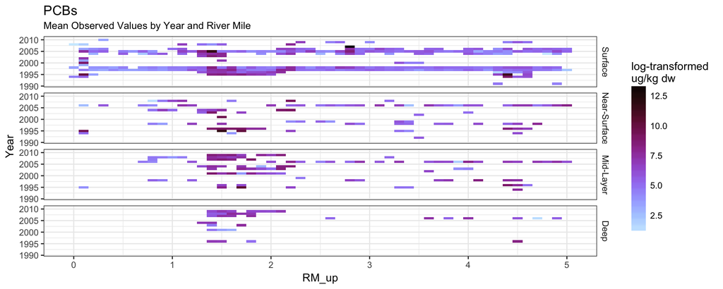

```r
for(chemical in names(chemlist)){
  chem_info<-chemlist[[chemical]]
  depth_plot<- ggplot() +  ggtitle(chemical, subtitle="Mean Observed Values by Year and River Mile") +
        # Rectangles to simulate core depths and values
         geom_tile(data=chem_simplified[chem==chemical&dredged_flag=="N"], # Exclude dredged areas, for now
                  aes(x=RM_up,y=Year, fill=log(obs_mean))) + # Color by log-value

         theme_bw() + scale_fill_gradientn(colors=wpal(chem_info[["colors"]])) +
         guides(fill=guide_colourbar(title=paste0("log-transformed \n",chem_info[["unit"]]),
                                     title.position="top", barheight=10,
                                     barwidth=1, label=TRUE, ticks=FALSE, direction="vertical")) +
        facet_wrap(~Depth,ncol=1,strip.position="right")+theme(strip.background = element_blank())
  print(depth_plot)
}
```

Upstream-Downstream patterns?

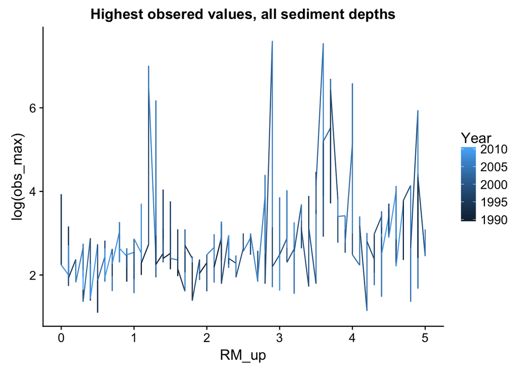

```r
  ggplot() +
  ggtitle("Highest obsered values, all sediment depths")+
        # Rectangles to simulate core depths and values
         geom_line(data=chem_[chem=="Arsenic"],
                  aes(x=RM_up,y=log(obs_max), color=Year)) # Color by log-value
```

Plotting the river, mile-by-mile:

```r
chemical<-"Arsenic"
chem_info<-chemlist[[chemical]]
var<-"RM"

# Let's see if we can find the dredged navigation channel/explore the dredging history
lim<-c(min(chem_data[chem==chemical][[var]],na.rm=T),max(chem_data[chem==chemical][[var]],na.rm=T))

full_map<-MapSuite::PointMap(coords=chem_data[chem==chemical],id="sp_index",xcol="X",ycol="Y",variable=var,
                  map_title="River Miles",map_colors = wpal("betafish"),
                  legend_position = "bottom", return_objects = T, legend_orientation = "horizontal",
                  include_titles=T, map_colors_limits = lim )$map

maps<-list()
for(river_mile in seq(0:3)){
maps[[paste0("RM_",river_mile)]]<-MapSuite::PointMap(coords=chem_data[chem==chemical &
                                                     (RM>=river_mile) & (RM<river_mile+ifelse(river_mile==3,1,2))],
                                                     map_title=paste0("RM ",river_mile,ifelse(river_mile==3,"+","")),
                                                     id="sp_index",xcol="X",ycol="Y",variable=var,
                                                     map_colors = wpal("betafish"),
                                                     legend_position = "none",
                                                     return_objects=T, map_colors_limits = lim,
                                                     include_titles = T)$map
}

plots_by_rivermile<-cowplot::plot_grid(maps[[1]],maps[[2]],maps[[3]],maps[[4]],align="h",nrow=1)
```

Plot the full length of the stream:

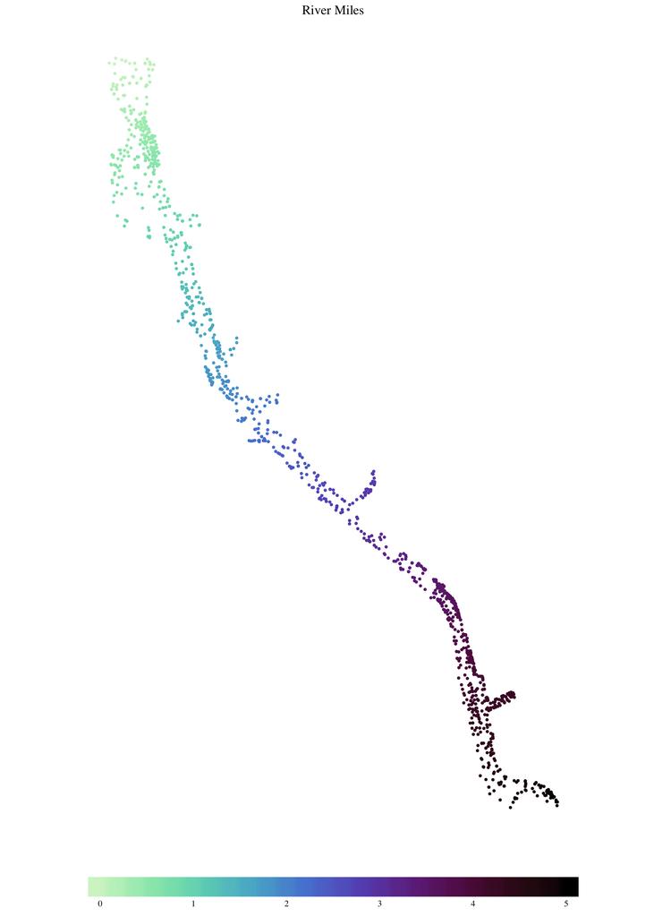

Plot by river-mile:

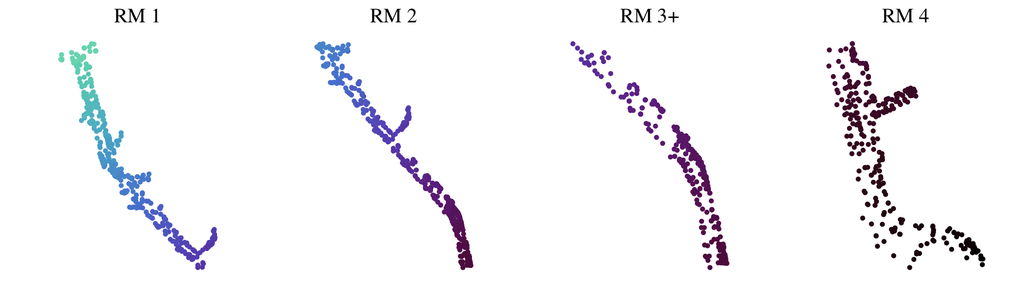